# Formative Assessment Report: Global Obesity and Diabetes Analysis

Pranit Chatterjee

Archie Barnett

Ankit Khatri

2025-11-10

# 1. Business Understanding

## Introduction

This report investigates the relationship between obesity and diabetes prevalence across countries and over time, with a particular focus on understanding gender differences. Using data from the Non-Communicable Disease Risk Factor Collaboration (NCD-RisC), we explore how these two critical health risk factors have evolved from 1990 to 2022.

## Research Questions

The analysis addresses the following key research questions:

1. How does obesity prevalence compare between countries over time?
2. Is there a relationship between obesity and diabetes prevalence globally?
3. Do gender differences exist in the obesity-diabetes relationship?
4. What trends can we observe in these health risk factors from 1990 to 2022?

## Key Performance Indicators (KPIs)

- **Prevalence of obesity (BMI ≥ 30 kg/m²):** Percentage of population classified as obese
- **Prevalence of diabetes (age 18+ years):** Age-standardized percentage with diabetes diagnosis
- **Temporal trends:** Changes in prevalence over 1990–2022
- **Gender comparisons:** Sex-stratified analysis for Men and Women
- **Country comparisons:** Focus on India, United Kingdom, and global aggregates

## Motivation

Understanding obesity and diabetes trends is critical for public health planning, policy development, and resource allocation. These conditions are major risk factors for cardiovascular disease, cancers, and other non-communicable diseases (NCDs). By examining trends and relationships, we can inform prevention strategies and identify high-risk populations.

# 2. Data Understanding

## Data Sources

This analysis uses two datasets from the NCD-RisC collaboration:

1. **BMI Dataset** (`NCD_RisC_Lancet_2024_BMI_age_standardised_country.csv`)
   - Contains age-standardized prevalence of BMI categories
   - Covers years 1990–2022
   - Stratified by sex (Men, Women)
   - Country-level and global aggregates
2. **Diabetes Dataset** (`NCD_RisC_Lancet_2024_Diabetes_age_standardised_countries.csv`)
   - Contains age-standardized diabetes prevalence (18+ years)
   - Covers years 1990–2022
   - Stratified by sex (Men, Women)
   - Country-level and global aggregates

## Data Loading and Initial Exploration

# Load required libraries

```r
library(dplyr)
```

```r
library(ggplot2)
library(tidyr)
library(knitr)
library(kableExtra)
```

# Load the dataset

```r
bmi <- read.csv("../data/NCD_RisC_Lancet_2024_BMI_age_standardised_country.csv")
diab <- read.csv("../data/NCD_RisC_Lancet_2024_Diabetes_age_standardised_countries.csv")
getwd()
```

```
## [1] "C:/Users/prani/Downloads/R Stats/11300607/NCD_RisC_CRISPDM_Analysis/reports"
```

# Display basic information

**BMI Dataset:**

```r
cat("Dimensions:", nrow(bmi), "rows,", ncol(bmi), "columns\n")
```

```
## Dimensions: 13200 rows, 34 columns
```

```r
cat("Year range:", min(bmi$Year), "to", max(bmi$Year), "\n")
```

```
## Year range: 1990 to 2022
```

```r
cat("Sex :", unique(bmi$Sex), "\n")
```

```
## Sex : Women Men
```

```r
cat("Number of countries/regions:", length(unique(bmi$Country.Region.World)), "\n\n")
```

```
## Number of countries/regions: 200
```

**Diabetes Dataset:**

```r
cat("Diabetes Dataset:\n")
```

```
## Diabetes Dataset:
```

```r
cat("Dimensions:", nrow(diab), "rows,", ncol(diab), "columns\n")
```

```
## Dimensions: 13200 rows, 11 columns
```

```r
cat("Year range:", min(diab$Year), "to", max(diab$Year), "\n")
```

```
## Year range: 1990 to 2022
```

```r
cat("Sex:", unique(diab$Sex), "\n")
```

```
## Sex: Men Women
```

```r
cat("Number of countries/regions:", length(unique(diab$Country.Region.World)), "\n")
```

```
## Number of countries/regions: 200
```

## Column names and Sample data

#Display first few rows of each dataset

```r
cat("First 6 rows of BMI dataset:\n")
```

```
## First 6 rows of BMI dataset:
```

```r
head(bmi[, 1:6])
```

|  | Year | Sex | Country.Region.World | ISO | Prevalence.of.BMI.18.5.kg.m...underweight. | Prevalence.of.BMI.18.5.kg.m...underweight..lower.95..uncertainty.interval |
| --- | --- | --- | --- | --- | --- | --- |
| 1 | 1990 | Women | Afghanistan | AFG | 0.3038631 | 0.2017575 |
| 2 | 1991 | Women | Afghanistan | AFG | 0.2957593 | 0.1965920 |
| 3 | 1992 | Women | Afghanistan | AFG | 0.2875977 | 0.1926961 |
| 4 | 1993 | Women | Afghanistan | AFG | 0.2794041 | 0.1880913 |
| 5 | 1994 | Women | Afghanistan | AFG | 0.2712061 | 0.1842866 |
| 6 | 1995 | Women | Afghanistan | AFG | 0.2629774 | 0.1792330 |

```r
cat("\n\nFirst 6 rows of Diabetes dataset:\n")
```

```
##
##
## First 6 rows of Diabetes dataset:
```

```r
head(diab[, 1:6])
```

|  | Country.Region.World | ISO | Sex | Year | Age | Prevalence.of.diabetes..18..years. |
| --- | --- | --- | --- | --- | --- | --- |
| 1 | Afghanistan | AFG | Men | 1990 | Age-standardised | 0.1021853 |
| 2 | Afghanistan | AFG | Men | 1991 | Age-standardised | 0.1041020 |
| 3 | Afghanistan | AFG | Men | 1992 | Age-standardised | 0.1061362 |
| 4 | Afghanistan | AFG | Men | 1993 | Age-standardised | 0.1082599 |
| 5 | Afghanistan | AFG | Men | 1994 | Age-standardised | 0.1104578 |
| 6 | Afghanistan | AFG | Men | 1995 | Age-standardised | 0.1127518 |

#Check unique values for key columns

```r
cat("Unique sexes in BMI:", unique(bmi$Sex), "\n")
```

```
## Unique sexes in BMI: Women Men
```

```r
cat("Unique sexes in Diabetes:", unique(diab$Sex), "\n")
```

```
## Unique sexes in Diabetes: Men Women
```

## Data Quality Summary

- **Completeness:** Both datasets contain data for 1990–2022 across multiple countries.
- **Sex stratification:** Data are available for both Men and Women.
- **Variables available:** BMI dataset includes obesity prevalence (BMI ≥ 30); Diabetes dataset includes diabetes prevalence for age 18+ years.
- **Missing data:** Initial inspection shows no obvious missing values in the key columns used for analysis.

# 3. Data Preparation

## Filtering and Cleaning

For this analysis, we focus on comparing **India and the United Kingdom** and examining **global patterns**. We will filter the datasets and select the relevant columns for merging and analysis.

# Filter for India and UK, all years (1990-2022)

```r
bmi_countries <- bmi |>
filter(Country.Region.World %in% c("India", "United Kingdom")) |>
select(Year, Sex, Country = Country.Region.World,
Obesity = Prevalence.of.BMI..30.kg.m...obesity.)

diab_countries <- diab |>
filter(Country.Region.World %in% c("India", "United Kingdom")) |>
select(Year, Sex, Country = Country.Region.World,
Diabetes = Prevalence.of.diabetes..18..years.)
```

# Merge BMI and Diabetes for India and UK

```r
merged_countries <- inner_join(bmi_countries, diab_countries,
by = c("Year", "Sex", "Country"))

cat("Merged data for India and UK:\n")
```

```
## Merged data for India and UK:
```

```r
print(head(merged_countries, 10))
```

```
##    Year   Sex Country    Obesity  Diabetes
## 1  1990 Women   India 0.01180674 0.1186107
## 2  1991 Women   India 0.01286921 0.1205610
## 3  1992 Women   India 0.01400993 0.1225091
## 4  1993 Women   India 0.01522892 0.1244348
## 5  1994 Women   India 0.01653412 0.1263249
## 6  1995 Women   India 0.01793202 0.1282764
## 7  1996 Women   India 0.01943285 0.1302627
## 8  1997 Women   India 0.02105097 0.1323238
## 9  1998 Women   India 0.02279459 0.1345069
## 10 1999 Women   India 0.02465342 0.1368859
```

```r
cat("\nDimensions:", nrow(merged_countries), "rows\n")
```

```
##
## Dimensions: 132 rows
```

# Filter for sex and single out data for investigating Diabetes and Obesity for people 30+ years old

```r
## Filter for male or female
Gender_Filter <- 'Men'
bmi_munged <- bmi |> filter(Sex == Gender_Filter) |> select(Year, Sex, `Country.Region.World`, `Prevalence.of.BMI..30.kg.m...obesity.`, `Prevalence.of.BMI..30.kg.m...obesity..lower.95..uncertainty.interval`, `Prevalence.of.BMI..30.kg.m...obesity..upper.95..uncertainty.interval`)

Diabetes_munged <- diab |> filter(Sex == Gender_Filter) |> select(`Country.Region.World`, Sex, Year, `Proportion.of.people.with.diabetes.who.were.treated..30..years.`, `Proportion.of.people.with.diabetes.who.were.treated..30..years..lower.95..uncertainty.interval`, `Proportion.of.people.with.diabetes.who.were.treated..30..years..upper.95..uncertainty.interval`)
```

# Merge Bmi and Diabetes for Sex and age 30+

```r
joined_bmi_diabetes <- full_join(bmi_munged, Diabetes_munged, by = c("Year", "Sex", "Country.Region.World"))
names(joined_bmi_diabetes)
```

```
## [1] "Year"
## [2] "Sex"
## [3] "Country.Region.World"
## [4] "Prevalence.of.BMI..30.kg.m...obesity."
## [5] "Prevalence.of.BMI..30.kg.m...obesity..lower.95..uncertainty.interval"
## [6] "Prevalence.of.BMI..30.kg.m...obesity..upper.95..uncertainty.interval"
## [7] "Proportion.of.people.with.diabetes.who.were.treated..30..years."
## [8] "Proportion.of.people.with.diabetes.who.were.treated..30..years..lower.95..uncertainty.interval"
## [9] "Proportion.of.people.with.diabetes.who.were.treated..30..years..upper.95..uncertainty.interval"
```

## Global Average Calculation

### bmi_gloabl -> Here we are calculating average/BMI prevelance for obese people(30 kg/m^2)

### diab_global -> we are calculating the average/mean prevalence of diabetes amongst people over 18 years of age

```r
bmi_global <- bmi %>%
group_by(Year, Sex) %>%
summarise(Obesity = mean(Prevalence.of.BMI..30.kg.m...obesity., na.rm=TRUE),
.groups='drop')

diab_global <- diab %>%
group_by(Year, Sex) %>%
summarise(Diabetes = mean(Prevalence.of.diabetes..18..years., na.rm=TRUE),
.groups='drop')
```

# Merged BMI and Diabetes dataset for sex 30+ years old

```r
joined_bmi_diabetes |>
                   summarise(across(where(is.numeric),
                                    list(mean = mean, sd = sd, min = min, median = median, max = max),
                                    .names = "{.col}_{.fn}")) |>
                   kable() |>
                   kable_styling()
```

| Year_mean | Year_sd | Year_min | Year_median | Year_max | Prevalence.of.BMI..30.kg.m…obesity._mean | Prevalence.of.BMI..30.kg.m…obesity._sd | Prevalence.of.BMI..30.kg.m…obesity._min | Prevalence.of.BMI..30.kg.m…obesity._median | Prevalence.of.BMI..30.kg.m…obesity._max | Prevalence.of.BMI..30.kg.m…obesity..lower.95..uncertainty.interval_mean | Prevalence.of.BMI..30.kg.m…obesity..lower.95..uncertainty.interval_sd | Prevalence.of.BMI..30.kg.m…obesity..lower.95..uncertainty.interval_min | Prevalence.of.BMI..30.kg.m…obesity..lower.95..uncertainty.interval_median | Prevalence.of.BMI..30.kg.m…obesity..lower.95..uncertainty.interval_max | Prevalence.of.BMI..30.kg.m…obesity..upper.95..uncertainty.interval_mean | Prevalence.of.BMI..30.kg.m…obesity..upper.95..uncertainty.interval_sd | Prevalence.of.BMI..30.kg.m…obesity..upper.95..uncertainty.interval_min | Prevalence.of.BMI..30.kg.m…obesity..upper.95..uncertainty.interval_median | Prevalence.of.BMI..30.kg.m…obesity..upper.95..uncertainty.interval_max | Proportion.of.people.with.diabetes.who.were.treated..30..years._mean | Proportion.of.people.with.diabetes.who.were.treated..30..years._sd | Proportion.of.people.with.diabetes.who.were.treated..30..years._min | Proportion.of.people.with.diabetes.who.were.treated..30..years._median | Proportion.of.people.with.diabetes.who.were.treated..30..years._max | Proportion.of.people.with.diabetes.who.were.treated..30..years..lower.95..uncertainty.interval_mean | Proportion.of.people.with.diabetes.who.were.treated..30..years..lower.95..uncertainty.interval_sd | Proportion.of.people.with.diabetes.who.were.treated..30..years..lower.95..uncertainty.interval_min | Proportion.of.people.with.diabetes.who.were.treated..30..years..lower.95..uncertainty.interval_median | Proportion.of.people.with.diabetes.who.were.treated..30..years..lower.95..uncertainty.interval_max | … |
| --- | --- | --- | --- | --- | --- | --- | --- | --- | --- | --- | --- | --- | --- | --- | --- | --- | --- | --- | --- | --- | --- | --- | --- | --- | --- | --- | --- | --- | --- | --- |
| 2006 | 9.522626 | 1990 | 2006 | 2022 | 0.1453205 | 0.1265103 | 0.0008371 | 0.1237858 | 0.7028932 | 0.1196768 | 0.114797 | 0.0005343 | 0.0967201 | 0.6306413 | 0.1745528 | 0.13907 | 0.0012426 | 0.1543111 | 0.7940023 | 0.3381739 | 0.1397739 | 0.0557261 | 0.3301816 | 0.7650776 | 0.2091764 | 0.1338762 | 0.0153918 | 0.1830837 | 0.6666673 | … |

# Merge global obesity and diabetes

### merged_global -> merges both mean obesity and diabetes indexes on a global level based on year and sex

```r
merged_global <- inner_join(bmi_global, diab_global, by = c("Year", "Sex"))

cat("Global mean obesity and diabetes by year and sex:\n")
```

```
## Global mean obesity and diabetes by year and sex:
```

```r
print(head(merged_global, 11))
```

```
## # A tibble: 11 × 4
##     Year Sex   Obesity Diabetes
##    <int> <chr>   <dbl>    <dbl>
##  1  1990 Men    0.0871   0.0754
##  2  1990 Women  0.148    0.0801
##  3  1991 Men    0.0900   0.0772
##  4  1991 Women  0.151    0.0821
##  5  1992 Men    0.0930   0.0789
##  6  1992 Women  0.155    0.0841
##  7  1993 Men    0.0960   0.0808
##  8  1993 Women  0.158    0.0861
##  9  1994 Men    0.0992   0.0826
## 10  1994 Women  0.162    0.0881
## 11  1995 Men    0.103    0.0845
```

# 4. Analysis and Visualization

## 4.1 Obesity and Diabetes Trends: India vs United Kingdom

### Obesity Trend (1990–2022)

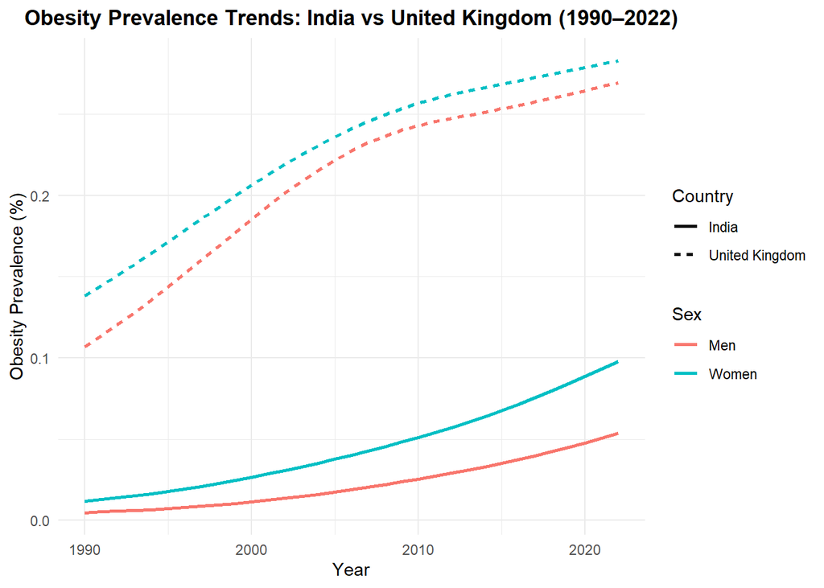

```r
ggplot(merged_countries, aes(x=Year, y=Obesity, color=Sex, linetype=Country)) +
geom_line(size=1) +
labs(title="Obesity Prevalence Trends: India vs United Kingdom (1990–2022)",
x="Year",
y="Obesity Prevalence (%)",
color="Sex",
linetype="Country") +
theme_minimal() +
theme(plot.title = element_text(hjust=0.5, face="bold"))
```

**Interpretation:** This plot shows how obesity prevalence has changed over time for men and women in India and the United Kingdom. We can observe how obesity has been increasing in each country and how the patterns differs by sex.

### Diabetes Trend (1990–2022)

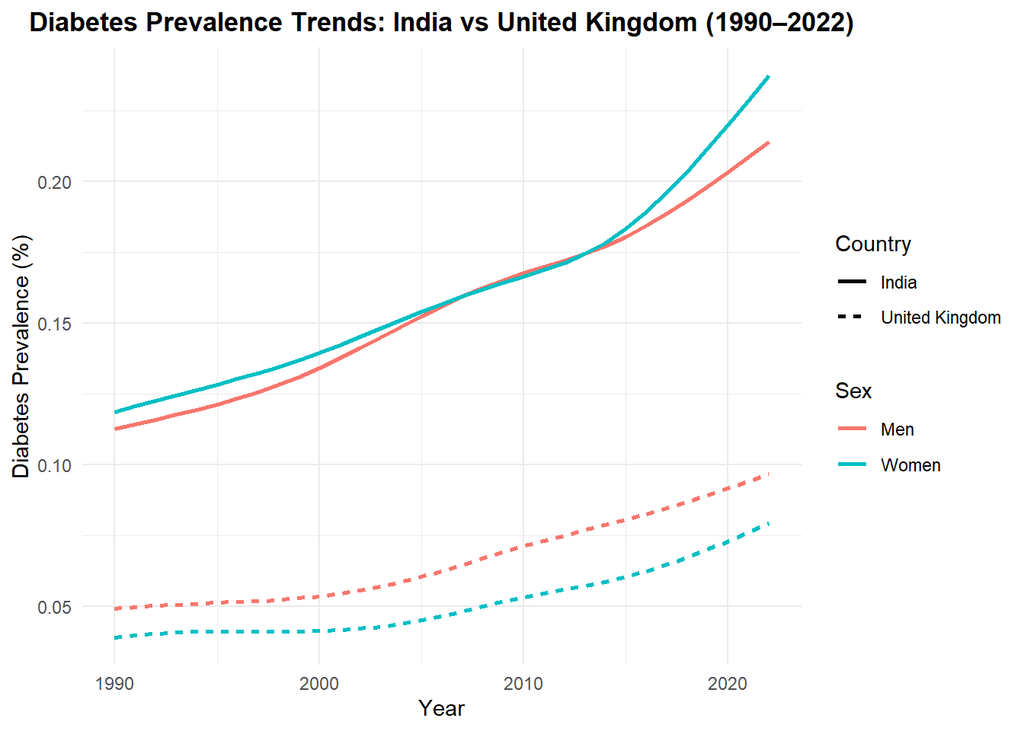

```r
ggplot(merged_countries, aes(x=Year, y=Diabetes, color=Sex, linetype=Country)) +
geom_line(size=1) +
labs(title="Diabetes Prevalence Trends: India vs United Kingdom (1990–2022)",
x="Year",
y="Diabetes Prevalence (%)",
color="Sex",
linetype="Country") +
theme_minimal() +
theme(plot.title = element_text(hjust=0.5, face="bold"))
```

**Interpretation:** This plot displays diabetes trends over the same period. We can assess whether diabetes prevalence has increased or decreased and whether the pattern mirrors obesity trends.

## 4.2 Relationship Between Obesity and Diabetes (2022)

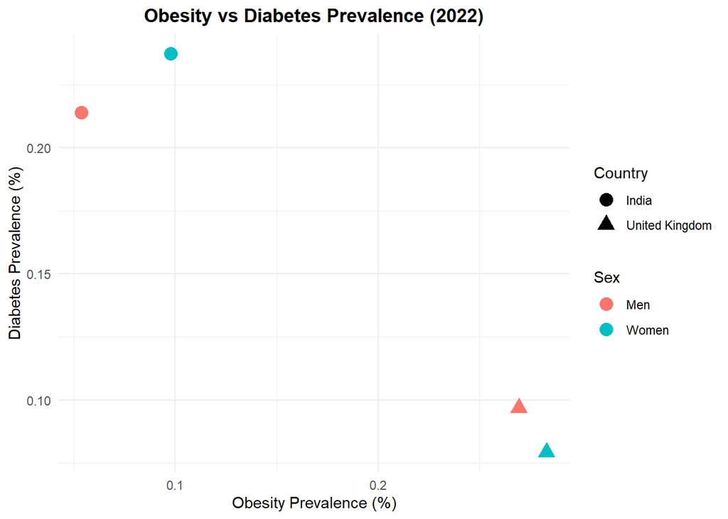

```r
merged_2022 <- merged_countries %>% filter(Year == 2022)

ggplot(merged_2022, aes(x=Obesity, y=Diabetes, color=Sex, shape=Country)) +
geom_point(size=4) +
labs(title="Obesity vs Diabetes Prevalence (2022)",
x="Obesity Prevalence (%)",
y="Diabetes Prevalence (%)",
color="Sex",
shape="Country") +
theme_minimal() +
theme(plot.title = element_text(hjust=0.5, face="bold"))
```

**Interpretation:** This scatter plot shows the direct relationship between obesity and diabetes prevalence in 2022 for India and the UK, stratified by sex. The positioning of the points indicates whether countries with higher obesity also have higher diabetes.

## 4.3 Global Obesity-Diabetes Correlation by Sex

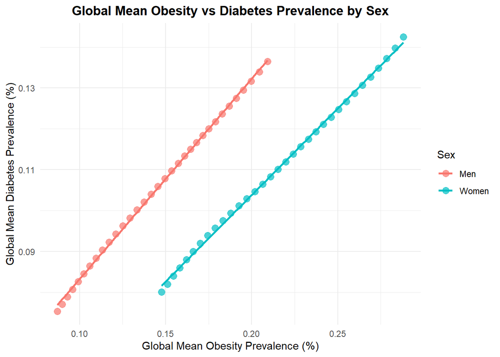

```r
ggplot(merged_global, aes(x=Obesity, y=Diabetes, color=Sex)) +
geom_point(size=3, alpha=0.7) +
geom_smooth(method="lm", se=FALSE, size=1) +
labs(title="Global Mean Obesity vs Diabetes Prevalence by Sex",
x="Global Mean Obesity Prevalence (%)",
y="Global Mean Diabetes Prevalence (%)",
color="Sex") +
theme_minimal() +
theme(plot.title = element_text(hjust=0.5, face="bold"))
```

**Interpretation:** This plot shows the correlation between global mean obesity and diabetes prevalence, with separate trend lines for men and women. A positive slope indicates that as obesity increases globally, diabetes also tends to increase.

## 4.4 Summary Statistics by Country and Sex (2022)

```r
summary_2022 <- merged_countries %>%
filter(Year == 2022) %>%
select(Country, Sex, Obesity, Diabetes) %>%
arrange(Country, Sex)

cat("Summary Statistics (2022):\n\n")
```

```
## Summary Statistics (2022):
```

```r
print(summary_2022)
```

```
##          Country   Sex    Obesity   Diabetes
## 1          India   Men 0.05380410 0.21389545
## 2          India Women 0.09779502 0.23745983
## 3 United Kingdom   Men 0.26939272 0.09680761
## 4 United Kingdom Women 0.28300061 0.07919639
```

## 4.5 Summary Statistics of a chosen variable for the merged Obesity and Diabetes by sex of individuals 30+ years old

```r
x <- joined_bmi_diabetes$`Proportion.of.people.with.diabetes.who.were.treated..30..years.`
joined_bmi_diabetes |>
                   summarise(
                      ds_mean = mean(x, na.rm = TRUE),
                      ds_sd = sd(x, na.rm = TRUE),
                      ds_min = min(x, na.rm = TRUE),
                      ds_median = median(x, na.rm = TRUE),
                      ds_max = max(x, na.rm = TRUE)
                   ) |>
                  kable(caption = "Summary Statistics for Variable X") |>
                  kable_styling(full_width = FALSE)
```

Summary Statistics for Variable X

| ds_mean | ds_sd | ds_min | ds_median | ds_max |
| --- | --- | --- | --- | --- |
| 0.3381739 | 0.1397739 | 0.0557261 | 0.3301816 | 0.7650776 |

**Interpretation** What we want from this is a general idea of the residual spread that our data points have. The values of x represents a Random Variable that has some form of distribution. We should look at the histogram to see if a good distribution can be found.

## 4.6 Histogram of random variable X

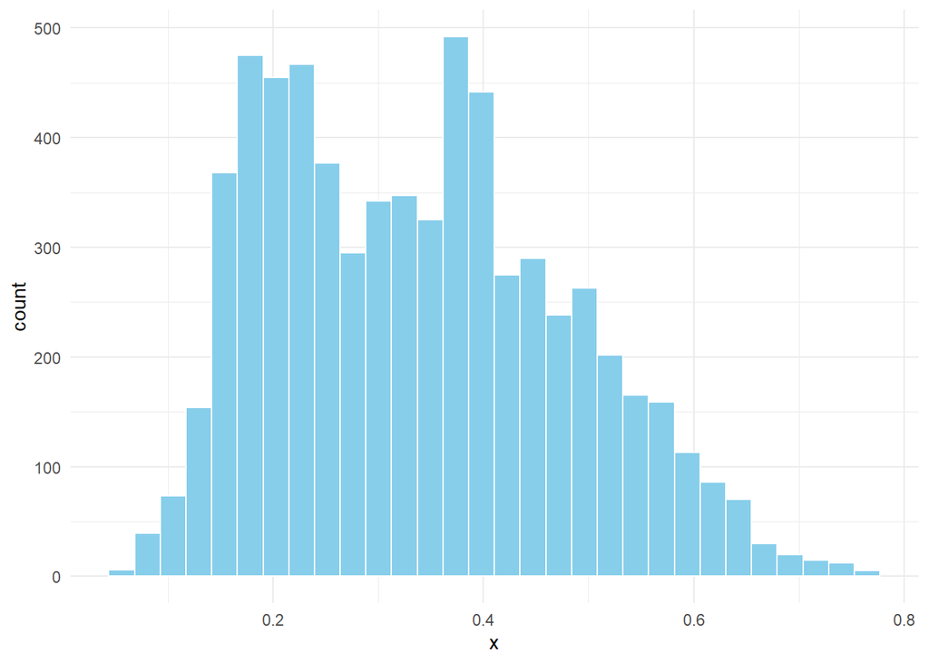

```r
ggplot(joined_bmi_diabetes, aes(x)) +
  geom_histogram(bins = 30, fill = "skyblue", color = "white") +
  theme_minimal()
```

## 4.7 Histogram of random variable X log e

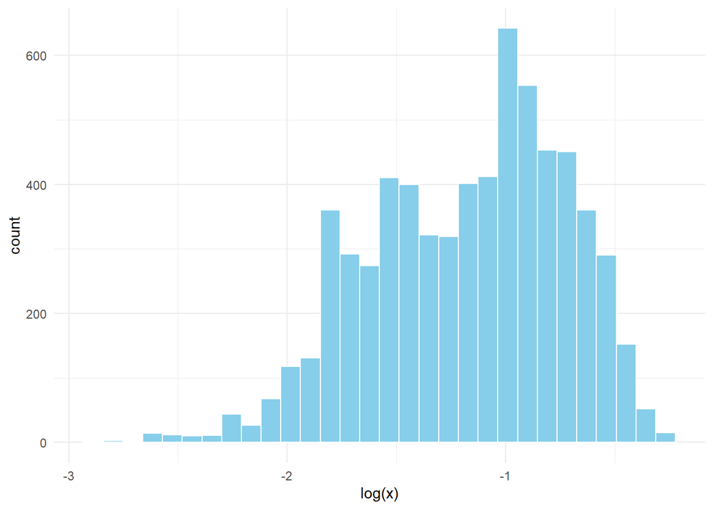

```r
ggplot(joined_bmi_diabetes, aes(log(x))) +
  geom_histogram(bins = 30, fill = "skyblue", color = "white") +
  theme_minimal()
```

## 4.8 Histogram of random variable X Square Rooted

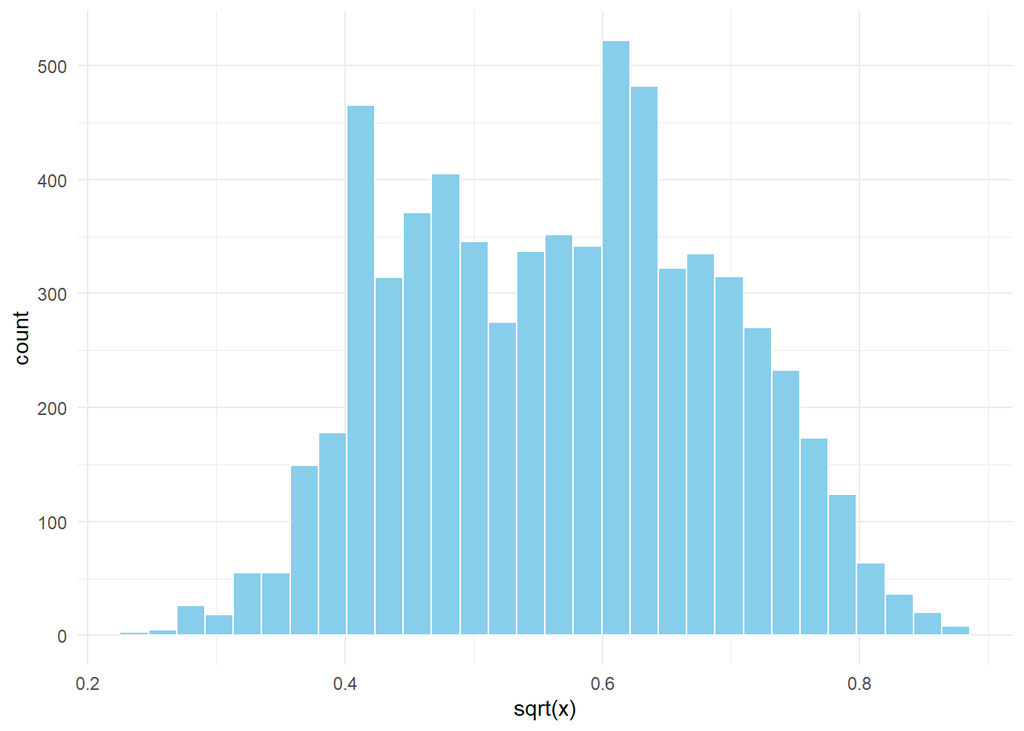

```r
ggplot(joined_bmi_diabetes, aes(sqrt(x))) +
  geom_histogram(bins = 30, fill = "skyblue", color = "white") +
  theme_minimal()
```

**Interpretation** There are improvements in certain features but still not great distribution. The curve itself is more central however, it lacks symmetry and there are multiple peeks which show that there isn’t a single high value which all the values fall into either the left or right hand side of the curve.

Despite the potential problems that may occur for having less normal distributions to this data point, the random variable x can always be changed to discover a better curve for analysis. In this case, its better we use this as a learning opportunity that sometimes transforming data points can help normalise results.

### Linear Regression: Global Mean Obesity vs Diabetes (Stratified by Sex)

#Fit linear regression models separately for Men and Women

```r
lm_men <- lm(Diabetes ~ Obesity, data = merged_global[merged_global$Sex=="Men", ])
lm_women <- lm(Diabetes ~ Obesity, data = merged_global[merged_global$Sex=="Women", ])
```

#Display model summaries

```r
cat("====== LINEAR REGRESSION MODEL: MEN ======\n")
```

```
## ====== LINEAR REGRESSION MODEL: MEN ======
```

```r
summary(lm_men)
```

```
##
## Call:
## lm(formula = Diabetes ~ Obesity, data = merged_global[merged_global$Sex ==
##     "Men", ])
##
## Residuals:
##        Min         1Q     Median         3Q        Max
## -0.0015434 -0.0003122  0.0001086  0.0004439  0.0006811
##
## Coefficients:
##              Estimate Std. Error t value Pr(>|t|)
## (Intercept) 0.0342570  0.0004014   85.34   <2e-16 ***
## Obesity     0.4901690  0.0026791  182.96   <2e-16 ***
## ---
## Signif. codes:  0 '***' 0.001 '**' 0.01 '*' 0.05 '.' 0.1 ' ' 1
##
## Residual standard error: 0.000562 on 31 degrees of freedom
## Multiple R-squared:  0.9991, Adjusted R-squared:  0.999
## F-statistic: 3.347e+04 on 1 and 31 DF,  p-value: < 2.2e-16
```

```r
cat("\n====== LINEAR REGRESSION MODEL: WOMEN ======\n")
```

```
##
## ====== LINEAR REGRESSION MODEL: WOMEN ======
```

```r
summary(lm_women)
```

```
##
## Call:
## lm(formula = Diabetes ~ Obesity, data = merged_global[merged_global$Sex ==
##     "Women", ])
##
## Residuals:
##        Min         1Q     Median         3Q        Max
## -0.0015402 -0.0003895 -0.0001978  0.0004880  0.0013807
##
## Coefficients:
##             Estimate Std. Error t value Pr(>|t|)
## (Intercept) 0.019169   0.000570   33.63   <2e-16 ***
## Obesity     0.423336   0.002596  163.10   <2e-16 ***
## ---
## Signif. codes:  0 '***' 0.001 '**' 0.01 '*' 0.05 '.' 0.1 ' ' 1
##
## Residual standard error: 0.0006305 on 31 degrees of freedom
## Multiple R-squared:  0.9988, Adjusted R-squared:  0.9988
## F-statistic: 2.66e+04 on 1 and 31 DF,  p-value: < 2.2e-16
```

**Good:**

> The linear regression models show a very strong and statistically significant association between global obesity prevalence and diabetes prevalence for both men and women, with R-squared values above 99%. This suggests that global obesity patterns explain most of the variation in diabetes rates according to this data**.**

**Limitations:**

> However, such a high R-squared may reflect the use of aggregated global data, which can mask variability within and between countries. The model does not account for other factors influencing diabetes, and assumptions should be checked with diagnostic plots.

### Linear Regression: Global Diabetes vs Obesity over time for a single sex of 30+ years

# Basic model for Diabetes vs Obesity

```r
plus_30_Obesity <- joined_bmi_diabetes$`Prevalence.of.BMI..30.kg.m...obesity.`
plus_30_Diabetes <- joined_bmi_diabetes$`Proportion.of.people.with.diabetes.who.were.treated..30..years.`
ds_Year <- joined_bmi_diabetes$Year

basic_lm <- lm(plus_30_Diabetes ~ plus_30_Obesity, data = joined_bmi_diabetes)
```

# Multi model for Diabetes vs Obesity + Time

```r
multi_lm <- lm(plus_30_Diabetes ~ plus_30_Obesity + ds_Year, data = joined_bmi_diabetes)
```

# Multi model for Diabetes vs Log(Obesity) + Time

```r
multi_log_lm <- lm(plus_30_Diabetes ~ log(plus_30_Obesity) + ds_Year, data = joined_bmi_diabetes)
```

# Model summaries

```r
cat("====== LINEAR REGRESSION MODEL: Basic ======\n")
```

```
## ====== LINEAR REGRESSION MODEL: Basic ======
```

```r
summary(basic_lm)
```

```
##
## Call:
## lm(formula = plus_30_Diabetes ~ plus_30_Obesity, data = joined_bmi_diabetes)
##
## Residuals:
##      Min       1Q   Median       3Q      Max
## -0.33086 -0.09962  0.00040  0.08734  0.40412
##
## Coefficients:
##                 Estimate Std. Error t value Pr(>|t|)
## (Intercept)     0.275208   0.002411  114.16   <2e-16 ***
## plus_30_Obesity 0.433288   0.012512   34.63   <2e-16 ***
## ---
## Signif. codes:  0 '***' 0.001 '**' 0.01 '*' 0.05 '.' 0.1 ' ' 1
##
## Residual standard error: 0.1286 on 6598 degrees of freedom
## Multiple R-squared:  0.1538, Adjusted R-squared:  0.1537
## F-statistic:  1199 on 1 and 6598 DF,  p-value: < 2.2e-16
```

```r
cat("====== LINEAR REGRESSION MODEL: Multiple ======\n")
```

```
## ====== LINEAR REGRESSION MODEL: Multiple ======
```

```r
summary(multi_lm)
```

```
##
## Call:
## lm(formula = plus_30_Diabetes ~ plus_30_Obesity + ds_Year, data = joined_bmi_diabetes)
##
## Residuals:
##      Min       1Q   Median       3Q      Max
## -0.30451 -0.09963  0.00478  0.09124  0.36828
##
## Coefficients:
##                  Estimate Std. Error t value Pr(>|t|)
## (Intercept)     -4.654895   0.342408  -13.60   <2e-16 ***
## plus_30_Obesity  0.379830   0.012868   29.52   <2e-16 ***
## ds_Year          0.002462   0.000171   14.40   <2e-16 ***
## ---
## Signif. codes:  0 '***' 0.001 '**' 0.01 '*' 0.05 '.' 0.1 ' ' 1
##
## Residual standard error: 0.1266 on 6597 degrees of freedom
## Multiple R-squared:  0.1796, Adjusted R-squared:  0.1793
## F-statistic:   722 on 2 and 6597 DF,  p-value: < 2.2e-16
```

```r
cat("====== LINEAR REGRESSION MODEL: Multiple + Transformed ======\n")
```

```
## ====== LINEAR REGRESSION MODEL: Multiple + Transformed ======
```

```r
summary(multi_log_lm)
```

```
##
## Call:
## lm(formula = plus_30_Diabetes ~ log(plus_30_Obesity) + ds_Year,
##     data = joined_bmi_diabetes)
##
## Residuals:
##      Min       1Q   Median       3Q      Max
## -0.30230 -0.08322  0.00562  0.07620  0.35531
##
## Coefficients:
##                        Estimate Std. Error t value Pr(>|t|)
## (Intercept)          -2.2570529  0.3224094  -7.001  2.8e-12 ***
## log(plus_30_Obesity)  0.0643027  0.0013675  47.022  < 2e-16 ***
## ds_Year               0.0013704  0.0001602   8.556  < 2e-16 ***
## ---
## Signif. codes:  0 '***' 0.001 '**' 0.01 '*' 0.05 '.' 0.1 ' ' 1
##
## Residual standard error: 0.1166 on 6597 degrees of freedom
## Multiple R-squared:  0.3044, Adjusted R-squared:  0.3042
## F-statistic:  1443 on 2 and 6597 DF,  p-value: < 2.2e-16
```